```python
%matplotlib inline
import matplotlib
matplotlib.style.use('ggplot')

import pandas as pd
import numpy as np
import matplotlib.pyplot as plt

Sd = pd.read_csv("stroopdata.csv")

x = p1data["Congruent"]
y = p1data["Incongruent"]
Sd.head()
```

|  | Congruent | Incongruent |
| --- | --- | --- |
| 0 | 12.079 | 19.278 |
| 1 | 16.791 | 18.741 |
| 2 | 9.564 | 21.214 |
| 3 | 8.630 | 15.687 |
| 4 | 14.669 | 22.803 |

# 1. What is our independent variable? What is our dependent variable?

the independent variable is whether the words name and color are same (congruent)or different(incongruent), and the dependent variable is the time to finish reading the word list.

# 2. What is an appropriate set of hypotheses for this task? What kind of statistical test do you expect to perform? Justify your choices.

my nullhypothese is that the average amount of time it takes to finish reading Incongruent list will be the same as the average time to finish reading congruent list

my alternative hypothese is that the average amount of time it takes to finish reading Incongruent list will be longer than the average time to finish reading congruent list

> H0: $\mu_{incongruent}$ - $\mu_{congruent}$ = 0

> H1: $\mu_{incongruent}$ - $\mu_{congruent}$ > 0

note: $\mu_{incongruent}$ is the population mean of incongruent list, $\mu_{congruent}$ is the population mean of congruent list

# 3. Report some descriptive statistics regarding this dataset. Include at least one measure of central tendency and at least one measure of variability.

```python
Sd.describe()
# mean for central tendency and std for variability
```

|  | Congruent | Incongruent |
| --- | --- | --- |
| count | 24.000000 | 24.000000 |
| mean | 14.051125 | 22.015917 |
| std | 3.559358 | 4.797057 |
| min | 8.630000 | 15.687000 |
| 25% | 11.895250 | 18.716750 |
| 50% | 14.356500 | 21.017500 |
| 75% | 16.200750 | 24.051500 |
| max | 22.328000 | 35.255000 |

# 4. Provide one or two visualizations that show the distribution of the sample data. Write one or two sentences noting what you observe about the plot or plots.

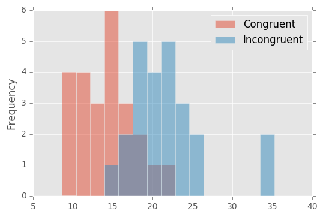

```python
Sd.plot.hist(bins =15,alpha =.5)
```

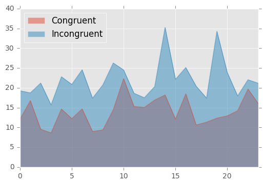

```python
Sd.plot.area(stacked=False,alpha =0.5)
```

From this graph we can also see observe the similar result as histgram shows, moreover, *we could also see that for every test, the time takes for Incongruent group is higher than that of congruent group*

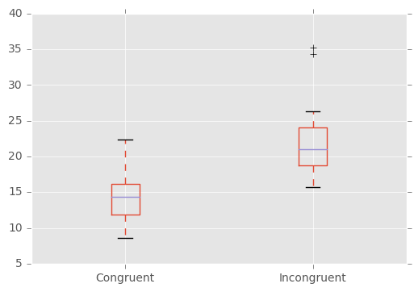

```python
Sd.plot.box()
```

From this graph we can also see observe the similar result as other graph shows, , we could see that the average time of incongruent list is about the max value of congruent list and the minimum value is at third quarter level of congruent list

# 5. Now, perform the statistical test and report your results. What is your confidence level and your critical statistic value? Do you reject the null hypothesis or fail to reject it? Come to a conclusion in terms of the experiment task. Did the results match up with your expectations?

```python
difference = Sd["Incongruent"]-Sd["Congruent"]
dstd = difference.std(ddof= 1)
sem = dstd / np.sqrt(24)
meandiff = difference.mean()
tnumber = meandiff/sem
cohensd = meandiff/dstd

print dstd, meandiff , sem, tnumber,cohensd
```

```
4.86482691036 7.96479166667 0.993028634778 8.02070694411 1.63721994912
```

[t table](https://s3.amazonaws.com/udacity-hosted-downloads/t-table.jpg)

> H0: $\mu_{incongruent}$ - $\mu_{congruent}$ = 0

> H1: $\mu_{incongruent}$ - $\mu_{congruent}$ > 0

$\bar{x}_{congruent}$ = 14.051125

$\bar{x}_{incongruent}$ = 22.015917

Mean of difference:

$\bar{x}_{difference}$ = 7.96479166667

standard deviation of difference:

$S_{difference}$ = 4.864826910359056

$SEM = \frac{S_{diff}}{\sqrt{n}}$ = 0.993028634778

$t = \frac{\bar{x}_{i} - \bar{x}_{c}}{SEM}$ = 8.02070694411

from t table, for one tail test, $\alpha$ = .05, 23 degree of freedom, $t_{critical}$ = 1.714

from our t value , we can see 8.02070694411 is larger than 1.714, so we should reject the null hypotheses

Cohen's d = $\frac{difference}{S}$ = 1.64

**So, in conclusion , we can see that it take significantly longer to complete the incongruent-condition task than the congruent-condition task.**

# 6. Optional: What do you think is responsible for the effects observed? Can you think of an alternative or similar task that would result in a similar effect? Some research about the problem will be helpful for thinking about these two questions!

I find several interesting theory in explaining the phenomenon

Processing speed

This theory suggests there is a lag in the brain's ability to recognize the color of the word since the brain reads words faster than it recognizes colors.[14] This is based on the idea that word processing is significantly faster th an color processing. In a condition where there is a conflict regarding words and colors (e.g., Stroop test), if the task is to report the color, the word information arrives at the decision-making stage before the color information which presents processing confusion. Conversely, if the task is to report the word, because color information lags after word information, a decision can be made ahead of the conflicting information.

Selective attention

The Selective Attention Theory that color recognition as opposed to reading a word, requires more attention, the brain needs to use more attention to recognize a color than to word encoding, so it takes a little longer.[16] The responses lend much to the interference noted in the Stroop task. This may be a result of either an allocation of attention to the responses or to a greater inhibition of distractors that are not appropriate responses.

Automaticity

This theory is the most common theory of the Stroop effect. It suggests that since recognizing colors is not an “automatic process” there is hesitancy to respond; whereas, the brain automatically understands the meaning of words as a result of habitual reading. This idea is based on the premise that automatic reading does not need controlled attention, but still uses enough attentional resources to reduce the amount of attention accessible for color information processing.Stirling (1979) introduced the concept of response automaticity. He demonstrated that changing the responses from colored words to letters that were not part of the colored words increased reaction time while reducing Stroop interference

Parallel distributed processing

This theory suggests that as the brain analyzes information, different and specific pathways are developed for different tasks. Some pathways, such as reading, are stronger than others, therefore, it is the strength of the pathway and not the speed of the pathway that is important. In addition, automaticity is a function of the strength of each pathway, hence, when two pathways are activated simultaneously in the Stroop effect, interference occurs between the stronger (word reading) path and the weaker (color naming) path, more specifically when the pathway that leads to the response is the weaker pathway.

source : https://en.wikipedia.org/wiki/Stroop_effect